# The Conquest of American Inflation

## A simple model

The government dislikes inflation $y_t$ and unemployment $U_t$ away from $0$. It seeks to set inflation to minimize

$$ L = \sum_{t=0}^\infty \beta^t r_t $$

for

$$ r_t = \frac{1}{2}\mathbb{E}\left[ U_t^2 + y_t^2 \right] $$

The only thing it needs is a theory of how inflation and unemployment are linked.

### The true economy

In the true economy, unemployment is determined by

$$ U_t = U^\star -\theta \left( y_t - x_t \right) $$

where $x_t$ is the mean forecast of inflation by the private sector. $U^\star$ is the "natural" rate of unemployment.

Moreover, we will also make the apparently inocent assumption that inflation $y_t$ is the sum of the government choice of inflation $\hat{y}_t$ plus an iid normally distributed shock $v_t$

### Expectations

The plot thickens because the government holds a misspecified model and instead attempts to fit a distributed-lag Phillips curve of the form

$$ U_t = \kappa y_t + \gamma' X_t + \epsilon^C_t $$

For most of this lecture we will set $X_t = [U_{t-1}, \dots, U_{t-M_u}, y_{t-1}, \dots, y_{t-M_y}, 1]'$. This means that the government forecasts unemployment with current inflation as well as lagged unemployment, lagged inflation, and a constant term.

Each period, the government updates its estimate of $\kappa$ and $\gamma$. An implementation of recursive least squares is to set

$\begin{aligned} \beta_t &= \beta_{t-1} + g_t R^{-1}_{X,t} X_t (U_t - \beta_{t-1}'X_t) \\ R_{X,t} &= R_{X,t-1} + g_t ( X_tX_t' - R_{X,t-1})\\ \end{aligned}$

where $\beta_t = [\kappa_t \; \gamma_t']'$. A key parameter is the "gain" parameter $g_t$, which governs the weight to be placed on newer observations. By setting $g_t = \frac{1}{t}$ one recovers the OLS scheme which weighs all observations the same. Setting the gain to a constant (or in general to a non square-summable sequence) makes the algorithm put more weight on recent observations, which can be useful if the analyst believes the data-generating process not to be stationary.

### The private sector's expectations

For the private sector, we consider three options.

```
1. Rational expectations
```

The simplest case is to make the private sector fully aware of the government's updating scheme and decision process. This amounts to setting $x_t = \hat{y}_t$ at all times.

```
2. Simple adaptive expectations
```

This is the 1950's model. Here we make the private sector's new forecast a function of old forecasting errors. That is, $$ x_t = x_{t-1} + (1-\lambda) (y_{t-1} - x_{t-1}) $$

```
3. Recursive least squares
```

Here we endow the private sector with a similar forecasting scheme to the government's. We initialize $g^p_0$ and $R_{X,0}^p$ at (maybe) different points than the government's and may use a different lag structure.

## Code

To manage the different expectation-formation schemes, the `ConquestEconomy` type records three different instances of a `PLM` type. Each `PLM` instance holds information about the expectations of a particular agent, including those of Nature, also known as the actual law of motion of the system.

```julia
using QuantEcon, LinearAlgebra, Random

using Plots
pyplot()

mutable struct PLM
  κ::Float64          # Weight on current state (unemployment or inflation)
  γ::Vector{Float64}  # Weights on lagged states (unemployment + inflation + constant)

  Mu::Int64           # Lags on unemployment
  My::Int64           # Lags on inflation

  classic::Bool       # TRUE for predicting unemployment with the state, FALSE for predicting inflation

  g::Float64          # Gain parameter (only for constant-gain RLS)
  R::Matrix{Float64}  # Variance matrix (only for RLS)
  λ::Float64          # Adaptation parameter (only for simple adaptive expectations)
end

mutable struct ConquestEconomy
  δ::Float64          # Discount factor

  plm_g::PLM          # Government's perceived law of motion
  plm_p::PLM          # Private sector's perceived law of motion
  alm::PLM            # Actual (Nature's perceived) law of motion

  private_expectations::String

  σe::Float64         # Variance of cost-push shock
  σc::Float64         # Variance of inflation control shock
end

lags(plm::PLM) = length(plm.γ)

function sum_coeff(plm::PLM) # Finds the sum of coefficients on (current and) lagged inflation
  if plm.classic
    current_term = plm.κ
  else
    current_term = 0
  end
  return sum(plm.γ[plm.Mu+1:plm.Mu+plm.My]) + current_term
end

get_Ustar(alm::PLM) = alm.γ[end]
get_θ(alm::PLM) = -alm.κ
get_Ustar(ce::ConquestEconomy) = get_Ustar(ce.alm)
get_θ(ce::ConquestEconomy) = get_θ(ce.alm)

function make_ALM(plmg::PLM, plmp::PLM, Ustar::Float64, θ::Float64)
  Mu = max(plmg.Mu, plmp.Mu)
  My = max(plmg.My, plmp.My)
  γ = [zeros(Mu+My); Ustar]
  κ = -θ
  alm = PLM(κ, γ, Mu, My, true, 0.0, plmg.R, plmg.λ) # In the ALM, all the forecasting variables are irrelevant
  return alm
end

make_ALM(ce::ConquestEconomy, Ustar=get_Ustar(ce), θ=get_θ(ce)) = make_ALM(ce.plm_g, ce.plm_p, Ustar, θ)
function update_ALM!(ce::ConquestEconomy)
  ce.alm = make_ALM(ce)
  nothing
end

function ConquestEconomy(;
  δ = 0.98,
  θ = 1.0,
  g = 0.05,
  λ = 0.5,  # λ is the weight on past observations for simple adaptive scheme
  σe = 0.5,
  σc = 0.5,
  Ustar = 5.0,
  classic = true,
  private_expectations = "rational",

  Mu = 1,
  My = 1,
  Mu_p = 2,
  My_p = 2
  )

  # Set arbitrary coefficients on past inflation and past unemployment
  γU = zeros(Mu)
  γy = zeros(My)
  γ = [γU; γy; 1]
  # For the induction hypothesis (weights on y's sum up to zero)
  κ = -sum(γy)
  R = zeros(Mu+My+1, Mu+My+1)

  plm_g = PLM(κ, γ, Mu, My, classic, g, R, λ)

  if private_expectations == "RLS"
    priv_gain = 0.01
  else
    Mu_p, My_p, priv_gain = Mu, My, g
  end
  Rp = zeros(Mu_p+My_p+1, Mu_p+My_p+1)
  classic = true # Always use the classical scheme for the private sector
  plm_p = PLM(1.0, [zeros(Mu_p+My_p);1], Mu_p, My_p, classic, priv_gain, Rp, λ)

  # True process
  alm = make_ALM(plm_g, plm_p, Ustar, θ)

  return ConquestEconomy(δ, plm_g, plm_p, alm, private_expectations, σe, σc)
end
```

```
ConquestEconomy
```

#### Some convenience functions to modify expectations schemes on the fly

```julia
function set_exp!(ce::ConquestEconomy, s::String=""; Mu=1, My=1, Mu_p=2, My_p=2)
  if s != "" && s != "rational" && s != "adaptive" && s != "RLS"
    println("WARNING: only 'rational', 'adaptive', and 'RLS' expectations allowed.")
  else
    if s == ""
      s = ce.private_expectations
    end
    ce2 = ConquestEconomy(private_expectations = s, Mu=Mu, My=My, Mu_p=Mu_p, My_p=My_p)
    ce.plm_p = ce2.plm_p
    ce.plm_g = ce2.plm_g
    ce.private_expectations = s
    update_ALM!(ce)
  end
  nothing
end

function set_exp!(ce::ConquestEconomy, n::Int64=0; Mu=1, My=1, Mu_p=2, My_p=2)
    if n == 0
        set_exp!(ce, "", Mu=Mu, My=My, Mu_p=Mu_p, My_p=My_p)
    else
    sv = ["rational"; "adaptive"; "RLS"]
    set_exp!(ce, sv[n], Mu=Mu, My=My, Mu_p=Mu_p, My_p=My_p)
    end
    nothing
end
```

```
set_exp! (generic function with 3 methods)
```

#### Aside

If $M_u$ and $M_y$ are large, the government's problem, which contains $X_t$ in its state, can be difficult to manage. This is why we resort to the immense power of a linear-quadratic formulation.

### Main building block: LQ problems

We want to make our problem have the form of choosing controls $u_t$ in state $x_t$ to minimize

$$ V(x) = \mathbb{E}[ x'Rx + u'Qu + 2 u'Nx + \beta V(x') ] $$

subject to

$$ x' = Ax + Bu + Cw $$

where $w$ are unit-variance iid normal shocks.

#### Setting up our problem

The first step is to make $r_t = X_t'RX_t + \hat{y}_t'Q\hat{y}_t + 2 \hat{y}_t'NX_t$. For this, notice that

$$ r_t = -\frac{1}{2} \left[ U_t^2 + y_t^2 \right] = -\frac{1}{2} \left[ \left( \kappa y_t + \gamma' X_t + \epsilon^C_t \right)^2 + y_t^2 \right] = -\frac{1}{2} \left[ \kappa^2 y_t^2 + X_t'\gamma\gamma'X_t + 2 X_t'\gamma\kappa y_t + y_t^2 \right] + k $$

where $k$ is a sum of terms that either have zero mean (like those coming from products between endogenous variables and $\epsilon_t^C$) or are independent of policy (like the square term in $\epsilon_t^C$).

This means that we can set $R = \gamma\gamma'$, $Q = [1+\kappa^2]$, and $N = \gamma\kappa$.

Turning to the law of motion, we want to write $X_{t+1} = [U_t,\dots, U_{t-M_u+1}, y_t, \dots, y_{t-M_y+1},1]'$ as $ X_{t+1} = AX_t + B \hat{y}_t + C w_{t+1}$. There are three parts: first, we will use the matrix $A$ to transfer lags of endogenous variables from $X_t$ to $X_{t+1}$. Second, we need to record $y_t$ (or equivalently, $\hat{y}_t$) and, finally, the value of $U_t$ *that the government expects*.

Since the government expects $\mathbb{E}^g[U_t] = \kappa y_t + \gamma'X_t$, we can set the first row of $A$ to coincide with $\gamma'$. We also set the first row of the (one-by-one) matrix $B$ to $\kappa$.

The matrix $A$ is then formed by

$\begin{aligned} A = \left( \begin{array}{cccc} [ && \gamma & ] \\ A_1 & 0 & 0 & 0 \\ 0 & 0 & 0 & 0 \\ 0 & 0 & A_2 & 0 \\ 0 & 0 & 0 & 1 \end{array}\right) \end{aligned}$

where $A_1$ is $M_u-1 \times M_u-1$ and $A_2$ is $M_y-1\times M_y-1$ and just shift the vectors by sending $U_{t-j}$ from the $j$th place to the $j+1$th place (and accordingly with $y$'s). The $1$ at the end takes care of the constant term (in the last element of $X$). The row of $0$'s (corresponding to $y_t$ in $X_{t+1}$) appears because we will fill the $y_t$ entry using the $B$ matrix.

Because $y_t = \hat{y}_t + v_t$, we can set $B = [\kappa,\dots, 0, 1, 0, \dots, 0]'$ with the $1$ in the $M_u+1$ place. Similarly for matrix $C$, only taking care with the variances

$\begin{aligned} C = \left( \begin{array}{cc} \sqrt{\sigma_e} & \kappa \sqrt{\sigma_c} \\ 0 & 0 \\ \dots & \dots \\ 0 & \sqrt{\sigma_c} \\ 0 & 0 \\ \dots & \dots \\ 0& 0 \end{array}\right) \end{aligned}$

```julia
function make_LQ(plm::PLM, δ, σc, σe)
  # Law of motion x_{t+1} = A x_t + B u_t + C w_{t+1}
  # u = mean inflation, y = u + σc ϵ

  if plm.classic
    κ, γ = plm.κ, plm.γ
  else
    # Invert the Phillips curve in the Keynesian formulation
    κ, γ = 1/plm.κ, -plm.γ / plm.κ
  end

  k = lags(plm)

  # Law of motion
  A = zeros(k, k)
  A[1,:] = γ[:]
  for jj in 1:plm.Mu-1
    A[jj+1, jj] = 1
  end
  for jj in 1:plm.My-1
    A[plm.Mu+jj+1, plm.Mu+jj] = 1
  end
  A[end,end] = 1

  B = zeros(k,1)
  B[1,1] = κ
  B[plm.Mu+1,1] = 1

  # Shocks: unemployment is affected directly by the cost-push shock and indirectly by the inflation control shock (κ-to-1), inflation affected directly by the control shock
  C = zeros(k,2)
  C[1,:] = [sqrt(σe) κ*sqrt(σc)]
  C[plm.Mu+1, 2] = sqrt(σc)

  # Set up objective function
  # r = x'Rx + u'Qu + 2 u'Nx

  Q = [1+κ^2 for ji in 1:1, jj in 1:1]
  R = γ * γ'
  N = [κ * γ[jj] for jy in 1:1, jj in 1:k]

  lq = QuantEcon.LQ(Q, R, A, B, C, N, bet = δ)
  return lq
end

function solve_Phelps!(lq::QuantEcon.LQ)
  try
    # Use QuantEcon's LQ solver
    P, F, d = stationary_values!(lq)

    # Bind states
    lq.P, lq.F, lq.d = P, F, d

  catch
    println("Default solver exited. Increasing maxiter.")
    # Increase number of iterations by hand
    Q, R, A, B, N, C = lq.Q, lq.R, lq.A, lq.B, lq.N, lq.C

    # solve Riccati equation, obtain P
    A0, B0 = sqrt(lq.bet) * A, sqrt(lq.bet) * B
    P = solve_discrete_riccati(A0, B0, R, Q, N, max_it=100)

    # Compute F
    s1 = Q .+ lq.bet * (B' * P * B)
    s2 = lq.bet * (B' * P * A) .+ N
    F = s1 \ s2

    # Compute d
    d = lq.bet * tr(P * C * C') / (1 - lq.bet)

    # Bind states
    lq.P, lq.F, lq.d = P, F, d
  end

  nothing
end
```

```
solve_Phelps! (generic function with 1 method)
```

#### Handling different state spaces for government and private agents

A challenge is to keep track of who knows which state. This is where the functions `expand_index` and `expand_matrix` come in handy

```julia
function expand_index(plm::PLM, alm::PLM, jj::Int64)
  new_j = jj
  if jj > plm.Mu && jj <= plm.Mu+plm.My
    new_j = alm.Mu - plm.Mu + jj
  elseif jj == plm.Mu + plm.My + 1
    new_j = alm.Mu + alm.My + 1
  end
  new_j
end

function expand_matrix(plm::PLM, alm::PLM, M::Matrix)
  A = zeros(expand_index(plm, alm, size(M,1)), expand_index(plm, alm, size(M,2)))

  for ji in 1:size(M,1)
    for jj in 1:size(M,2)
      A[expand_index(plm, alm, ji), expand_index(plm, alm, jj)] = M[ji,jj]
    end
  end
  A
end
```

```
expand_matrix (generic function with 1 method)
```

```julia
function simul_PLM(ce::ConquestEconomy, plm::PLM)
  lq = make_LQ(plm, ce.δ, ce.σc, ce.σe)

  xpath, upath, wpath = compute_sequence(lq, ones(lags(plm)))
end

function update_PC_OLS!(plm::PLM, alm::PLM, Ut, yt, Xt)

  if plm.classic
    predicted_var = Ut
    predictor_var = yt
  else
    predicted_var = yt
    predictor_var = Ut
  end

  # States has lags on unemployment, lags on inflation, and the constant
  States = [Xt[1:plm.Mu]; Xt[alm.Mu+1:alm.Mu+plm.My]; Xt[end]]

  # OLS formula U_t = κ y_t + γ'X_t + ϵ_t
  X = [predictor_var States']'

  # Implement OLS inv(x'x)x'y with x \ y
  new_γ = X' \ predicted_var

  # Bind coefficients
  plm.κ = new_γ[1]
  plm.γ = new_γ[2:end]

  new_γ
end

function update_PC_RLS!(plm::PLM, alm::PLM, Ut, yt, Xt)

  if plm.classic
    predicted_var = Ut
    predictor_var = yt
  else
    predicted_var = yt
    predictor_var = Ut
  end

  # States has lags on unemployment, lags on inflation, and the constant
  States = [Xt[1:plm.Mu]; Xt[alm.Mu+1:alm.Mu+plm.My]; Xt[end]]

  X = [predictor_var States']'

  old_γ = [plm.κ; plm.γ[1:end]]

  # Use RLS updating formulas
  new_R = plm.R + plm.g * (X*X' - plm.R)
  new_γ = old_γ + plm.g * (new_R \ (X*(predicted_var - old_γ'*X)))

  # Bind new coefficients
  plm.κ = new_γ[1]
  plm.γ = new_γ[2:end]
  plm.R = new_R

  new_γ
end
```

```
update_PC_RLS! (generic function with 1 method)
```

```julia
function simul_reest(ce::ConquestEconomy, T=50; OLS::Bool=false)
  Random.seed!(1)

  # Unpack and prepare
  plm_g, plm_p, alm = ce.plm_g, ce.plm_p, ce.alm
  expectations = ce.private_expectations
  alm_lq = make_LQ(alm, ce.δ, ce.σc, ce.σe)
  solve_Phelps!(alm_lq)

  # Initial state
  xv, uv, wv = simul_PLM(ce, plm_p)
  initial_T = 50
  xv, uv, wv = xv[:,end-initial_T:end], uv[:,end-initial_T+1:end], wv[:,end-initial_T:end]
  xnew = xv[:,end]

  # Ensure the constant is a constant (mostly redundant)
  xv[end,end] = 1

  # Initial variance matrix
  yvec = xv[alm.Mu+1, 2:end]
  States_vec = vcat(xv[1:plm_g.Mu,1:end-1], xv[alm.Mu+1:alm.Mu+plm_g.My, 1:end-1], xv[end:end, 1:end-1])
  X = [yvec States_vec']'
  plm_g.γ = zeros(size(plm_g.γ))
  plm_g.κ = 0.0
  plm_g.R = X*X'

  # Initialize private sector
  States_vec = vcat(xv[1:plm_p.Mu,1:end-1], xv[alm.Mu+1:alm.Mu+plm_p.My, 1:end-1], xv[end:end, 1:end-1])
  X = [yvec States_vec']'
  plm_p.R = X*X'
  x_priv = 0.0

  # Initialize vectors to store results
  svec = ones(size(xv,2)-1) * sum_coeff(plm_g)
  κvec = ones(size(xv,2)-1) * plm_g.κ
  γvec = [plm_g.γ[jj] for jy in 1:1, jj in 1:lags(plm_g)]
  πv = vcat(yvec, zeros(T))
  Uv = vcat(xv[1, 2:end], zeros(T))

  for jj in initial_T+1:initial_T+T
    if OLS
      plm_g.g = min(plm_g.g, 1/jj)
    end

    Xt = xnew

    # Gov't chooses its action
    lq = make_LQ(plm_g, ce.δ, ce.σc, ce.σe)
    solve_Phelps!(lq)

    # Private sector sets expectations
    Fp = zeros(1, lags(plm_p))
    if expectations == "adaptive" || expectations == "RLS"
      Fp[1,end] = x_priv # Add expected inflation in the constant term
    elseif expectations == "rational"
      Fp = expand_matrix(plm_g, plm_p, lq.F)
    end

    # Nature determines the natural rate given current private expectations
    θ = get_θ(alm)
    Ustar = get_Ustar(alm) + (θ * expand_matrix(plm_p, alm, -Fp) * Xt)[1]
    alm_lq.A[1,end] = Ustar

    # Gov't implements choice of action

    unew = expand_matrix(plm_g, alm, -lq.F) * Xt

    # Nature sets the state with the real model
    shocks = randn(2)
    wnew = alm_lq.C * (shocks .* [sqrt(ce.σe), sqrt(ce.σc)])
    xnew = alm_lq.A*xnew + alm_lq.B*unew + wnew

    # Save output and unemployment
    Ut = xnew[1]
    yt = xnew[alm.Mu+1]

    # Private sector updates expectations for tomorrow
    if expectations == "adaptive"
      x_priv = x_priv + (1-plm_p.λ) * ((unew[1] + shocks[2]) - x_priv)
    end
    if expectations == "RLS"
      update_PC_RLS!(plm_p, alm, Ut, yt, xnew)
      lq_p = make_LQ(plm_g, ce.δ, ce.σc, ce.σe)
      solve_Phelps!(lq_p)

      x_priv = (expand_matrix(plm_g, alm, -lq_p.F) * Xt)[1]
    end

    # Government updates
    new_γ = update_PC_RLS!(plm_g, alm, Ut, yt, Xt)
    κvec = [κvec; plm_g.κ]
    svec = [svec; sum_coeff(plm_g)]
    γvec = [γvec; plm_g.γ']

    Uv[jj] = Ut
    πv[jj] = yt
  end

  print("Finished simulation with $expectations expectations")
  labels = ["Unemployment" "Inflation" "PC slope coefficient" "Sum of lagged coefficients"]
  pl = plot([Uv πv κvec svec], layout=4, title=labels, size = (900,450), color=[2 3 5 8], palette=:heat, bg="#fafafa", ticks=:auto, leg=false)
  return pl
end
```

```
simul_reest (generic function with 2 methods)
```

```
Finished simulation with rational expectations
```

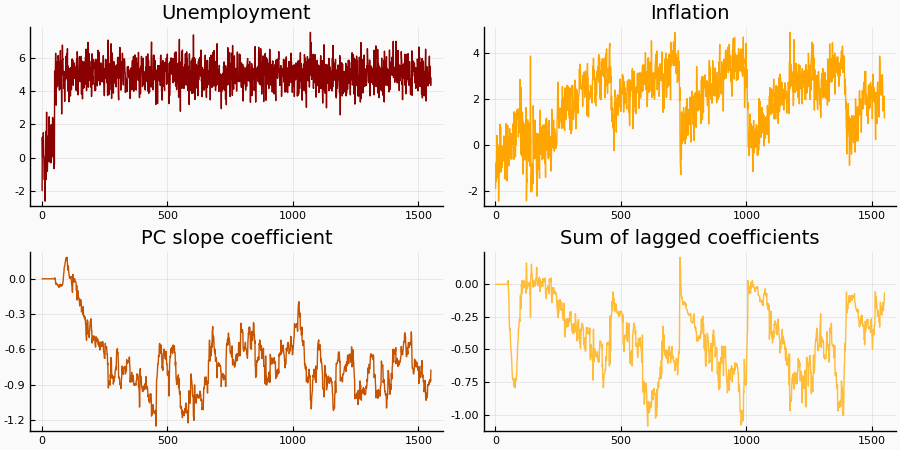

```julia
ce = ConquestEconomy(); set_exp!(ce, 1)
simul_reest(ce, 1500)
```

```
Finished simulation with rational expectations
```

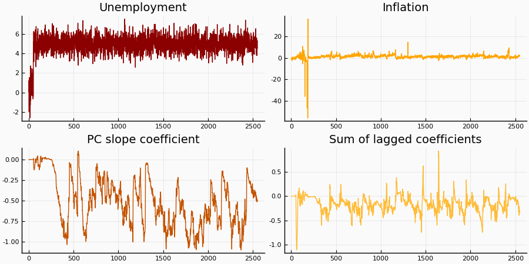

```julia
ce = ConquestEconomy(Mu=5,My=7) # With more lags in the government's specification, similar dynamics emerge but the pattern becomes more complicated
simul_reest(ce, 2500)
```

```
Finished simulation with adaptive expectations
```

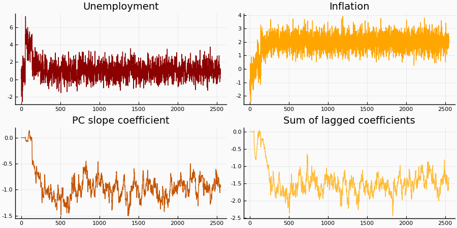

```julia
ce = ConquestEconomy(); set_exp!(ce, 2)
simul_reest(ce, 2500)
```

```
Finished simulation with RLS expectations
```

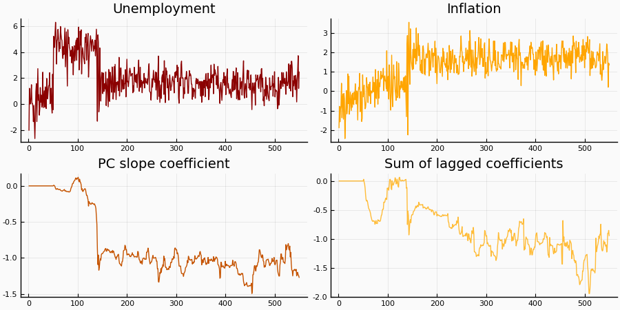

```julia
ce = ConquestEconomy(); set_exp!(ce, 3)
simul_reest(ce, 500)
```